# Intro to DS - PCA / PCR

today

# USDA Nutrient Dataset

This data was from USDA National Nutrient dataset, pre-processed by @craigkelly from data.world.

## Preparation

### Question 1

**Import the dataset**  
Import the dataset into R. There should be 45 variables. Take a quick look at the data. Just str, head, and tail will do for now.

```r
data <- read.csv(file='USDANationalNutrient.csv',
                 header=T, sep=',', fill=T, strip.white=T,
                 blank.lines.skip=T)
rmarkdown::paged_table(head(data))
```

|  | ID | FoodGroup | ShortDescrip | Descrip | CommonName | MfgName | ScientificName | Energy_kcal | Protein_g | Fat_g | Carb_g | Sugar_g | Fiber_g | VitA_mcg | VitB6_mg | VitB12_mcg | VitC_mg | VitE_mg | Folate_mcg | Niacin_mg | Riboflavin_mg | Thiamin_mg | Calcium_mg | Copper_mcg | Iron_mg | Magnesium_mg | Manganese_mg | Phosphorus_mg | Selenium_mcg | … |
| --- | --- | --- | --- | --- | --- | --- | --- | --- | --- | --- | --- | --- | --- | --- | --- | --- | --- | --- | --- | --- | --- | --- | --- | --- | --- | --- | --- | --- | --- | --- |
| 1 | 1001 | Dairy and Egg Products | BUTTER,WITH SALT | Butter, salted |  |  |  | 717 | 0.85 | 81.1 | 0.06 | 0.06 | 0 | 684 | 0.003 | 0.17 | 0 | 2.32 | 3 | 0.042 | 0.034 | 0.005 | 24 | 0.000 | 0.02 | 2 | 0.000 | 24 | 1.0 | … |
| 2 | 1002 | Dairy and Egg Products | BUTTER,WHIPPED,WITH SALT | Butter, whipped, with salt |  |  |  | 717 | 0.85 | 81.1 | 0.06 | 0.06 | 0 | 684 | 0.003 | 0.13 | 0 | 2.32 | 3 | 0.042 | 0.034 | 0.005 | 24 | 0.016 | 0.16 | 2 | 0.004 | 23 | 1.0 | … |
| 3 | 1003 | Dairy and Egg Products | BUTTER OIL,ANHYDROUS | Butter oil, anhydrous |  |  |  | 876 | 0.28 | 99.5 | 0.00 | 0.00 | 0 | 840 | 0.001 | 0.01 | 0 | 2.80 | 0 | 0.003 | 0.005 | 0.001 | 4 | 0.001 | 0.00 | 0 | 0.000 | 3 | 0.0 | … |
| 4 | 1004 | Dairy and Egg Products | CHEESE,BLUE | Cheese, blue |  |  |  | 353 | 21.40 | 28.7 | 2.34 | 0.50 | 0 | 198 | 0.166 | 1.22 | 0 | 0.25 | 36 | 1.016 | 0.382 | 0.029 | 528 | 0.040 | 0.31 | 23 | 0.009 | 387 | 14.5 | … |
| 5 | 1005 | Dairy and Egg Products | CHEESE,BRICK | Cheese, brick |  |  |  | 371 | 23.24 | 29.7 | 2.79 | 0.51 | 0 | 292 | 0.065 | 1.26 | 0 | 0.26 | 20 | 0.118 | 0.351 | 0.014 | 674 | 0.024 | 0.43 | 24 | 0.012 | 451 | 14.5 | … |
| 6 | 1006 | Dairy and Egg Products | CHEESE,BRIE | Cheese, brie |  |  |  | 334 | 20.75 | 27.7 | 0.45 | 0.45 | 0 | 174 | 0.235 | 1.65 | 0 | 0.24 | 65 | 0.380 | 0.520 | 0.070 | 184 | 0.019 | 0.50 | 20 | 0.034 | 188 | 14.5 | … |

```r
str(data)
```

```
## 'data.frame':    8618 obs. of  45 variables:
##  $ ID              : int  1001 1002 1003 1004 1005 1006 1007 1008 1009 1010 ...
##  $ FoodGroup       : chr  "Dairy and Egg Products" "Dairy and Egg Products" "Dairy and Egg Products" "Dairy and Egg Products" ...
##  $ ShortDescrip    : chr  "BUTTER,WITH SALT" "BUTTER,WHIPPED,WITH SALT" "BUTTER OIL,ANHYDROUS" "CHEESE,BLUE" ...
##  $ Descrip         : chr  "Butter, salted" "Butter, whipped, with salt" "Butter oil, anhydrous" "Cheese, blue" ...
##  $ CommonName      : chr  "" "" "" "" ...
##  $ MfgName         : chr  "" "" "" "" ...
##  $ ScientificName  : chr  "" "" "" "" ...
##  $ Energy_kcal     : num  717 717 876 353 371 334 300 376 406 387 ...
##  $ Protein_g       : num  0.85 0.85 0.28 21.4 23.24 ...
##  $ Fat_g           : num  81.1 81.1 99.5 28.7 29.7 ...
##  $ Carb_g          : num  0.06 0.06 0 2.34 2.79 0.45 0.46 3.06 1.33 4.78 ...
##  $ Sugar_g         : num  0.06 0.06 0 0.5 0.51 0.45 0.46 0 0.28 0 ...
##  $ Fiber_g         : num  0 0 0 0 0 0 0 0 0 0 ...
##  $ VitA_mcg        : num  684 684 840 198 292 174 241 271 263 233 ...
```

[output cut: 31 more lines]

```r
# Please don't get me wrong for using this as the html becomes too wide I had to use this.
rmarkdown::paged_table(tail(data))
```

|  | ID | FoodGroup | ShortDescrip | Descrip | CommonName | MfgName | ScientificName | Energy_kcal | Protein_g | Fat_g | Carb_g | Sugar_g | Fiber_g | VitA_mcg | VitB6_mg | VitB12_mcg | VitC_mg | VitE_mg | Folate_mcg | Niacin_mg | Riboflavin_mg | Thiamin_mg | Calcium_mg | Copper_mcg | Iron_mg | Magnesium_mg | Manganese_mg | Phosphorus_mg | Selenium_mcg | … |
| --- | --- | --- | --- | --- | --- | --- | --- | --- | --- | --- | --- | --- | --- | --- | --- | --- | --- | --- | --- | --- | --- | --- | --- | --- | --- | --- | --- | --- | --- | --- |
| 8613 | 80200 | Finfish and Shellfish Products | FROG LEGS,RAW | Frog legs, raw |  |  |  | 73 | 16.4 | 0.30 | 0.00 | 0.0 | 0 | 15 | 0.120 | 0.40 | 0 | 1.00 | 15 | 1.20 | 0.250 | 0.140 | 18 | 0.250 | 1.50 | 20 | 0.000 | 147 | 14.1 | … |
| 8614 | 83110 | Finfish and Shellfish Products | MACKEREL,SALTED | Fish, mackerel, salted |  |  |  | 305 | 18.5 | 25.10 | 0.00 | 0.0 | 0 | 47 | 0.410 | 12.00 | 0 | 2.38 | 15 | 3.30 | 0.190 | 0.020 | 66 | 0.100 | 1.40 | 60 | 0.000 | 254 | 73.4 | … |
| 8615 | 90240 | Finfish and Shellfish Products | SCALLOP,(BAY&SEA),CKD,STMD | Mollusks, scallop, (bay and sea), cooked, steamed |  |  |  | 111 | 20.5 | 0.84 | 5.41 | 0.0 | 0 | 2 | 0.112 | 2.15 | 0 | 0.00 | 20 | 1.08 | 0.024 | 0.012 | 10 | 0.033 | 0.58 | 37 | 0.029 | 426 | 21.7 | … |
| 8616 | 90480 | Sweets | SYRUP,CANE | Syrup, Cane |  |  |  | 269 | 0.0 | 0.00 | 73.14 | 73.2 | 0 | 0 | 0.000 | 0.00 | 0 | 0.00 | 0 | 0.10 | 0.060 | 0.130 | 13 | 0.020 | 3.60 | 10 | 0.000 | 8 | 0.7 | … |
| 8617 | 90560 | Finfish and Shellfish Products | SNAIL,RAW | Mollusks, snail, raw |  |  |  | 90 | 16.1 | 1.40 | 2.00 | 0.0 | 0 | 30 | 0.130 | 0.50 | 0 | 5.00 | 6 | 1.40 | 0.120 | 0.010 | 10 | 0.400 | 3.50 | 250 | 0.000 | 272 | 27.4 | … |
| 8618 | 93600 | Finfish and Shellfish Products | TURTLE,GREEN,RAW | Turtle, green, raw |  |  |  | 89 | 19.8 | 0.50 | 0.00 | 0.0 | 0 | 30 | 0.120 | 1.00 | 0 | 0.50 | 15 | 1.10 | 0.150 | 0.120 | 118 | 0.250 | 1.40 | 20 | 0.000 | 180 | 16.8 | … |

### Question 2

**Drop the first 7 variables**  
Save the rest as a dataframe, and call it `nndf1`.

```r
nndf1 <- data[, seq(-7, -1)]
colnames(nndf1)
```

```
##  [1] "Energy_kcal"      "Protein_g"        "Fat_g"            "Carb_g"
##  [5] "Sugar_g"          "Fiber_g"          "VitA_mcg"         "VitB6_mg"
##  [9] "VitB12_mcg"       "VitC_mg"          "VitE_mg"          "Folate_mcg"
## [13] "Niacin_mg"        "Riboflavin_mg"    "Thiamin_mg"       "Calcium_mg"
## [17] "Copper_mcg"       "Iron_mg"          "Magnesium_mg"     "Manganese_mg"
## [21] "Phosphorus_mg"    "Selenium_mcg"     "Zinc_mg"          "VitA_USRDA"
## [25] "VitB6_USRDA"      "VitB12_USRDA"     "VitC_USRDA"       "VitE_USRDA"
## [29] "Folate_USRDA"     "Niacin_USRDA"     "Riboflavin_USRDA" "Thiamin_USRDA"
## [33] "Calcium_USRDA"    "Copper_USRDA"     "Magnesium_USRDA"  "Phosphorus_USRDA"
## [37] "Selenium_USRDA"   "Zinc_USRDA"
```

## OLS full model

### Question 3

**Issue with full OLS models**  
All the variables are now numerical. Let us build a quick model (full model) to predict `Energy_kcal`, and another full model to predict `VitB12_mcg`. (No fancy output is required.) Vegetarian diet can often be low on B12, which makes one get tired easier. Having a model could be useful. What are the NAs for the coefficients mean? (Try google.)

```r
quick_model_energy <- lm(Energy_kcal~., data=nndf1)
quick_model_vitb12 <- lm(VitB12_mcg~., data=nndf1)

# quick_model_energy
# summary(quick_model_energy)
```

```r
# quick_model_vitb12
# summary(quick_model_vitb12)
```

NAs are caused by multicollinearities in the predictor variables. One or more of the vectors in the predictor set can be reproduced by a linear combination of other vectors. For vectors to be linearly independent, the linear combination of them should yield 0 only using a trivial solution (all coefficients of linear combination must be 0).

### Question 4

**Fix duplicate/collinear variables**  
You probably realize where the problem comes from. Alright then, let us

- only keep the first 23 columns,
- standardize all the variables, and
- the save the resulting dataframe as `nndf`

```r
nndf <- scale(as.matrix(nndf1[, seq(1, 23)]))
nndf <- data.frame(nndf)
xkablesummary(nndf)
```

Table: Statistics summary.

|  | Energy_kcal | Protein_g | Fat_g | Carb_g | Sugar_g | Fiber_g | VitA_mcg | VitB6_mg | VitB12_mcg | VitC_mg | VitE_mg | Folate_mcg | Niacin_mg | Riboflavin_mg | Thiamin_mg | Calcium_mg | Copper_mcg | Iron_mg | Magnesium_mg | Manganese_mg | Phosphorus_mg | Selenium_mcg | Zinc_mg |
| --- | --- | --- | --- | --- | --- | --- | --- | --- | --- | --- | --- | --- | --- | --- | --- | --- | --- | --- | --- | --- | --- | --- | --- |
| Min | Min. :-1.34 | Min. :-1.09 | Min. :-0.67 | Min. :-0.801 | Min. :-0.48 | Min. :-0.47 | Min. :-0.1 | Min. :-0.55 | Min. :-0.28 | Min. :-0.1 | Min. :-0.2 | Min. :-0.27 | Min. :-0.71 | Min. :-0.5 | Min. :-0.4 | Min. :-0.4 | Min. :-0.31 | Min. :-0.47 | Min. :-0.58 | Min. :-0.1 | Min. :-0.8 | Min. :-0.4 | Min. :-0.59 |
| Q1 | 1st Qu.:-0.79 | 1st Qu.:-0.86 | 1st Qu.:-0.61 | 1st Qu.:-0.800 | 1st Qu.:-0.48 | 1st Qu.:-0.47 | 1st Qu.:-0.1 | 1st Qu.:-0.48 | 1st Qu.:-0.28 | 1st Qu.:-0.1 | 1st Qu.:-0.2 | 1st Qu.:-0.27 | 1st Qu.:-0.63 | 1st Qu.:-0.4 | 1st Qu.:-0.3 | 1st Qu.:-0.3 | 1st Qu.:-0.26 | 1st Qu.:-0.38 | 1st Qu.:-0.41 | 1st Qu.:-0.1 | 1st Qu.:-0.6 | 1st Qu.:-0.4 | 1st Qu.:-0.52 |
| Median | Median :-0.21 | Median :-0.31 | Median :-0.34 | Median :-0.473 | Median :-0.46 | Median :-0.40 | Median :-0.1 | Median :-0.30 | Median :-0.27 | Median :-0.1 | Median :-0.2 | Median :-0.23 | Median :-0.27 | Median :-0.2 | Median :-0.3 | Median :-0.3 | Median :-0.17 | Median :-0.24 | Median :-0.23 | Median :-0.1 | Median :-0.1 | Median :-0.3 | Median :-0.34 |
| Mean | Mean : 0.00 | Mean : 0.00 | Mean : 0.00 | Mean : 0.000 | Mean : 0.00 | Mean : 0.00 | Mean : 0.0 | Mean : 0.00 | Mean : 0.00 | Mean : 0.0 | Mean : 0.0 | Mean : 0.00 | Mean : 0.00 | Mean : 0.0 | Mean : 0.0 | Mean : 0.0 | Mean : 0.00 | Mean : 0.00 | Mean : 0.00 | Mean : 0.0 | Mean : 0.0 | Mean : 0.0 | Mean : 0.00 |
| Q3 | 3rd Qu.: 0.65 | 3rd Qu.: 0.80 | 3rd Qu.: 0.21 | 3rd Qu.: 0.407 | 3rd Qu.:-0.09 | 3rd Qu.: 0.09 | 3rd Qu.:-0.1 | 3rd Qu.: 0.19 | 3rd Qu.: 0.02 | 3rd Qu.:-0.1 | 3rd Qu.:-0.1 | 3rd Qu.:-0.14 | 3rd Qu.: 0.33 | 3rd Qu.: 0.1 | 3rd Qu.: 0.0 | 3rd Qu.:-0.1 | 3rd Qu.:-0.05 | 3rd Qu.:-0.02 | 3rd Qu.:-0.07 | 3rd Qu.: 0.0 | 3rd Qu.: 0.3 | 3rd Qu.: 0.3 | 3rd Qu.: 0.22 |
| Max | Max. : 3.99 | Max. : 7.28 | Max. : 5.63 | Max. : 2.870 | Max. : 6.85 | Max. :17.84 | Max. :38.4 | Max. :24.52 | Max. :22.61 | Max. :41.5 | Max. :38.6 | Max. :31.25 | Max. :25.67 | Max. :38.4 | Max. :44.7 | Max. :36.2 | Max. :26.90 | Max. :21.11 | Max. :13.35 | Max. :51.3 | Max. :48.1 | Max. :67.3 | Max. :26.50 |

Obtain a simple correlation matrix for the dataframe. If you use the function `xkabledply()` on the correlation matrix, it will print out a nice scrollable table for html and your console output.

```r
rmarkdown::paged_table(data.frame(cor(nndf)))
```

|  | Energy_kcal | Protein_g | Fat_g | Carb_g | Sugar_g | Fiber_g | VitA_mcg | VitB6_mg | VitB12_mcg | VitC_mg | VitE_mg | Folate_mcg | Niacin_mg | Riboflavin_mg | Thiamin_mg | Calcium_mg | Copper_mcg | Iron_mg | Magnesium_mg | Manganese_mg | Phosphorus_mg | Selenium_mcg | Zinc_mg |
| --- | --- | --- | --- | --- | --- | --- | --- | --- | --- | --- | --- | --- | --- | --- | --- | --- | --- | --- | --- | --- | --- | --- | --- |
| Energy_kcal | 1.0000 | 0.11030 | 0.806795 | 0.48710 | 0.31315 | 0.19734 | 0.02633 | 0.1219 | -0.01229 | -0.03349 | 0.3037 | 0.14594 | 0.1750 | 0.1558 | 0.18744 | 0.12357 | 0.09951 | 0.1956 | 0.25588 | 0.037621 | 0.1952 | 0.05667 | 0.1128 |
| Protein_g | 0.1103 | 1.00000 | 0.054715 | -0.30197 | -0.26617 | -0.07278 | 0.02648 | 0.2285 | 0.24542 | -0.06646 | -0.0295 | 0.00894 | 0.3769 | 0.2025 | 0.09836 | 0.04689 | 0.15890 | 0.1264 | 0.21861 | 0.039742 | 0.4446 | 0.37837 | 0.4163 |
| Fat_g | 0.8068 | 0.05472 | 1.000000 | -0.05412 | -0.00196 | -0.02884 | 0.02438 | -0.0469 | -0.02079 | -0.05999 | 0.3380 | -0.05805 | -0.0227 | -0.0363 | -0.00579 | 0.01504 | 0.04276 | -0.0404 | 0.07078 | -0.000592 | 0.0661 | 0.03756 | 0.0283 |
| Carb_g | 0.4871 | -0.30197 | -0.054116 | 1.00000 | 0.61534 | 0.45819 | 0.00187 | 0.1956 | -0.09464 | 0.07675 | 0.0703 | 0.32517 | 0.1733 | 0.2324 | 0.28181 | 0.18911 | 0.06211 | 0.3505 | 0.28721 | 0.055570 | 0.0732 | -0.11460 | -0.0122 |
| Sugar_g | 0.3132 | -0.26617 | -0.001962 | 0.61534 | 1.00000 | 0.11592 | 0.01014 | 0.0888 | -0.05045 | 0.06415 | 0.0661 | 0.16126 | 0.0344 | 0.1252 | 0.09775 | 0.12954 | -0.00584 | 0.1178 | 0.04131 | 0.010871 | -0.0498 | -0.12371 | -0.0220 |
| Fiber_g | 0.1973 | -0.07278 | -0.028842 | 0.45819 | 0.11592 | 1.00000 | 0.00591 | 0.2428 | -0.05205 | 0.08185 | 0.1602 | 0.24908 | 0.1353 | 0.1577 | 0.20521 | 0.23229 | 0.18504 | 0.3867 | 0.54204 | 0.101661 | 0.1584 | -0.03590 | 0.0852 |
| VitA_mcg | 0.0263 | 0.02648 | 0.024379 | 0.00187 | 0.01014 | 0.00591 | 1.00000 | 0.1366 | 0.58100 | 0.11128 | 0.0441 | 0.10852 | 0.1517 | 0.3257 | 0.05292 | 0.03482 | 0.56994 | 0.1035 | 0.02457 | 0.369993 | 0.0558 | 0.04804 | 0.0705 |
| VitB6_mg | 0.1219 | 0.22849 | -0.046950 | 0.19557 | 0.08877 | 0.24280 | 0.13660 | 1.0000 | 0.26432 | 0.27130 | 0.2861 | 0.55009 | 0.7141 | 0.5817 | 0.41701 | 0.17727 | 0.11633 | 0.4779 | 0.29317 | 0.066876 | 0.2134 | 0.10900 | 0.4471 |
| VitB12_mcg | -0.0123 | 0.24542 | -0.020786 | -0.09464 | -0.05045 | -0.05205 | 0.58100 | 0.2643 | 1.00000 | 0.00726 | 0.0606 | 0.15848 | 0.2790 | 0.4362 | 0.09960 | 0.01171 | 0.57064 | 0.1773 | 0.00412 | 0.242112 | 0.1488 | 0.21531 | 0.2981 |
| VitC_mg | -0.0335 | -0.06646 | -0.059993 | 0.07675 | 0.06415 | 0.08185 | 0.11128 | 0.2713 | 0.00726 | 1.00000 | 0.0669 | 0.07280 | 0.2091 | 0.2259 | 0.05699 | 0.11183 | 0.02546 | 0.0744 | 0.11522 | 0.017942 | 0.0120 | -0.03522 | 0.0185 |

[output cut: 13 more lines]

### Question 5

**VitB12_mcg**  
Build a quick full model again for “VitB12_mcg”. What is the $R^2$ value? Notice that using PCA won’t improve the $R^2$. It will only match it if you use all 22 PC-components (1 target, 22 explanatory variables). However, this can be the baseline number to compare.

```r
quick_model_vitb12 <- lm(VitB12_mcg~., data=nndf)
quick_model_vitb12
```

```
##
## Call:
## lm(formula = VitB12_mcg ~ ., data = nndf)
##
## Coefficients:
##   (Intercept)    Energy_kcal      Protein_g          Fat_g         Carb_g
##     -2.45e-15       2.36e-01      -1.35e-02      -2.30e-01      -2.31e-01
##       Sugar_g        Fiber_g       VitA_mcg       VitB6_mg        VitC_mg
##      1.26e-02      -1.94e-02       2.24e-01       1.52e-01      -7.53e-02
##       VitE_mg     Folate_mcg      Niacin_mg  Riboflavin_mg     Thiamin_mg
##      9.71e-03      -3.79e-02      -8.67e-02       3.29e-01      -1.18e-01
##    Calcium_mg     Copper_mcg        Iron_mg   Magnesium_mg   Manganese_mg
##     -7.34e-02       3.74e-01       5.19e-02      -2.21e-01       1.02e-01
## Phosphorus_mg   Selenium_mcg        Zinc_mg
##      7.34e-02       8.25e-02       6.81e-02
```

```r
summary(quick_model_vitb12)
```

```
##
## Call:
## lm(formula = VitB12_mcg ~ ., data = nndf)
##
## Residuals:
##    Min     1Q Median     3Q    Max
## -8.468 -0.138 -0.031  0.087 21.720
##
## Coefficients:
##                Estimate Std. Error t value Pr(>|t|)
## (Intercept)   -2.45e-15   6.93e-03    0.00  1.00000
## Energy_kcal    2.36e-01   7.64e-02    3.09  0.00201 **
## Protein_g     -1.35e-02   2.24e-02   -0.60  0.54649
## Fat_g         -2.30e-01   6.36e-02   -3.61  0.00031 ***
## Carb_g        -2.31e-01   4.98e-02   -4.63  3.7e-06 ***
## Sugar_g        1.26e-02   9.33e-03    1.35  0.17728
## Fiber_g       -1.94e-02   9.86e-03   -1.97  0.04880 *
## VitA_mcg       2.24e-01   9.93e-03   22.54  < 2e-16 ***
## VitB6_mg       1.52e-01   1.13e-02   13.52  < 2e-16 ***
## VitC_mg       -7.53e-02   7.66e-03   -9.83  < 2e-16 ***
## VitE_mg        9.71e-03   8.02e-03    1.21  0.22585
## Folate_mcg    -3.79e-02   9.78e-03   -3.87  0.00011 ***
## Niacin_mg     -8.67e-02   1.40e-02   -6.21  5.7e-10 ***
## Riboflavin_mg  3.29e-01   1.29e-02   25.42  < 2e-16 ***
## Thiamin_mg    -1.18e-01   1.00e-02  -11.81  < 2e-16 ***
## Calcium_mg    -7.34e-02   9.52e-03   -7.71  1.4e-14 ***
## Copper_mcg     3.74e-01   9.86e-03   37.87  < 2e-16 ***
## Iron_mg        5.19e-02   9.71e-03    5.35  9.1e-08 ***
## Magnesium_mg  -2.21e-01   1.02e-02  -21.73  < 2e-16 ***
## Manganese_mg   1.02e-01   7.75e-03   13.18  < 2e-16 ***
## Phosphorus_mg  7.34e-02   1.05e-02    7.00  2.8e-12 ***
## Selenium_mcg   8.25e-02   7.58e-03   10.89  < 2e-16 ***
## Zinc_mg        6.81e-02   8.92e-03    7.63  2.5e-14 ***
## ---
## Signif. codes:  0 '***' 0.001 '**' 0.01 '*' 0.05 '.' 0.1 ' ' 1
##
## Residual standard error: 0.644 on 8595 degrees of freedom
## Multiple R-squared:  0.587,  Adjusted R-squared:  0.586
## F-statistic:  555 on 22 and 8595 DF,  p-value: <2e-16
```

The adjusted $R^2$ is 0.586 is almost the same as Multiple $R^2$. Hence the variables that we had included weren’t too bad.

## PCA

### Question 6

**PCA decomposition**  
Instead of PCR, let us run the PCA on this dataset. The dataframe is already centered and scaled. Use  
`nnpcomp <- prcomp(nndf)` to get the 23 PC-components. For `PC1`, which are the four strongest components it consists of?  
(Ans: Riboflavin_mg at -0.3413, Niacin_mg at -0.3378, and so forth.)  
And which are the four strongest for `PC2`?

```r
nncomp <- prcomp(nndf)
nncomp
```

```
## Standard deviations (1, .., p=23):
##  [1] 2.3344 1.6182 1.4254 1.3708 1.2789 1.0679 1.0300 0.9624 0.9284 0.9081
## [11] 0.8551 0.7726 0.7132 0.6852 0.6387 0.5813 0.5741 0.5668 0.5062 0.4880
## [21] 0.4595 0.3989 0.0616
##
## Rotation (n x k) = (23 x 23):
##                   PC1     PC2     PC3     PC4      PC5     PC6     PC7      PC8
## Energy_kcal   -0.1578  0.2734 -0.4620  0.0523 -0.29360  0.1329  0.0668 -0.07441
## Protein_g     -0.1406 -0.3434 -0.2136 -0.3111  0.01318  0.1415  0.0063 -0.11631
## Fat_g         -0.0330  0.1117 -0.5341  0.0265 -0.39445 -0.1165  0.0453  0.04959
## Carb_g        -0.1697  0.4434  0.0498  0.1741  0.08272  0.2794  0.0221 -0.15508
## Sugar_g       -0.0763  0.3588  0.0552  0.2174 -0.04842  0.3370  0.2986 -0.14351
## Fiber_g       -0.1816  0.2577 -0.0404  0.0421  0.33216 -0.1349 -0.4147 -0.18781
## VitA_mcg      -0.1335 -0.2365 -0.0219  0.5304  0.00814 -0.0390  0.1013  0.04623
## VitB6_mg      -0.3157 -0.0211  0.1746 -0.1144 -0.13375 -0.2005  0.0247 -0.08325
## VitB12_mcg    -0.1780 -0.3550 -0.0128  0.3466 -0.05886  0.1231  0.0561 -0.00451
## VitC_mg       -0.0876  0.0385  0.1623  0.0476  0.02471 -0.5452  0.4513 -0.51594
## VitE_mg       -0.1371  0.1064 -0.2073  0.0262 -0.23802 -0.4753 -0.1254  0.14856
## Folate_mcg    -0.2841  0.0971  0.2310 -0.0325 -0.13770  0.0547 -0.1309  0.16220
## Niacin_mg     -0.3378 -0.0848  0.1649 -0.1564 -0.20343 -0.0263  0.0457 -0.01054
## Riboflavin_mg -0.3413 -0.0735  0.1921  0.0470 -0.15346  0.0508  0.1418  0.04470
## Thiamin_mg    -0.2725  0.0752  0.1844 -0.1035 -0.16152  0.1300 -0.0718  0.19047
## Calcium_mg    -0.1681  0.1052 -0.1281 -0.0993  0.38869 -0.0705  0.4628  0.36701
## Copper_mcg    -0.1808 -0.2127 -0.1523  0.3899  0.16124  0.0862 -0.1192 -0.18793
## Iron_mg       -0.2999  0.0938  0.0871 -0.0594  0.09711  0.0305 -0.1333  0.10759
## Magnesium_mg  -0.2413  0.1034 -0.2012 -0.0718  0.35274 -0.1401 -0.2696 -0.19157
## Manganese_mg  -0.0936 -0.0888 -0.0726  0.3114  0.12560 -0.1825 -0.1365  0.34595
## Phosphorus_mg -0.1994 -0.0874 -0.2748 -0.2079  0.34493  0.0838  0.3235  0.17026
## Selenium_mcg  -0.0923 -0.2393 -0.1634 -0.1616 -0.00505  0.2438 -0.0219 -0.41036
## Zinc_mg       -0.2436 -0.1778 -0.0386 -0.1663 -0.06432  0.0545 -0.1059 -0.03395
##                   PC9    PC10    PC11     PC12    PC13     PC14     PC15
## Energy_kcal    0.0415  0.1411  0.1402 -0.11714  0.0577 -0.06694  0.03919
## Protein_g      0.1485  0.0184  0.3071  0.12954  0.3110  0.08569 -0.13219
## Fat_g         -0.0916  0.2007  0.0540 -0.20185 -0.1041 -0.10225  0.03302
## Carb_g         0.1178 -0.0440  0.0261  0.02825  0.1132 -0.00990  0.09298
## Sugar_g        0.1511 -0.3880  0.0795  0.22802 -0.0217  0.11557 -0.13877
## Fiber_g       -0.0658  0.0866 -0.0462 -0.09937  0.2653 -0.05426  0.53572
## VitA_mcg      -0.0220  0.1181 -0.0311 -0.07857  0.1042 -0.10760 -0.08160
## VitB6_mg       0.0230 -0.1981  0.0573 -0.00917  0.3526 -0.30781  0.00708
## VitB12_mcg    -0.1321 -0.1332 -0.0621 -0.07148  0.2148  0.01869  0.21636
```

[output cut: 47 more lines]

```
## VitB12_mcg     0.003647
## VitC_mg       -0.005337
## VitE_mg       -0.001255
## Folate_mcg     0.002718
## Niacin_mg      0.001081
## Riboflavin_mg -0.001516
## Thiamin_mg     0.001987
## Calcium_mg     0.000653
## Copper_mcg    -0.004497
## Iron_mg       -0.002589
## Magnesium_mg  -0.008817
## Manganese_mg  -0.000699
## Phosphorus_mg -0.007263
## Selenium_mcg   0.001062
## Zinc_mg        0.000223
```

In `PC1` Riboflavin_mg at -0.3413, Niacin_mg at -0.3378, VitB6_mg at -0.3157, and Iron_mg at -0.2999 are the four strong components.  
In `PC2` Carb_g at 0.4434, Sugar_g at 0.3588, Protein_g at -0.3434, VitB12_mcg at -0.3550 are the four strong components.

### Question 7

**BiPlots**  
Make a biplot between `PC1` and `PC2` like this: `biplot( nnpcomp, c(1,2), scale=0 )`. Continue to plot `PC1` with `PC3` (use `c(1,3)`), `c(1,4)`, `c(1,5)`, and `c(1,6)`. Also make biplots for `c(2,3)`, `c(3,4)`, `c(4,5)`, `c(5,6)`.

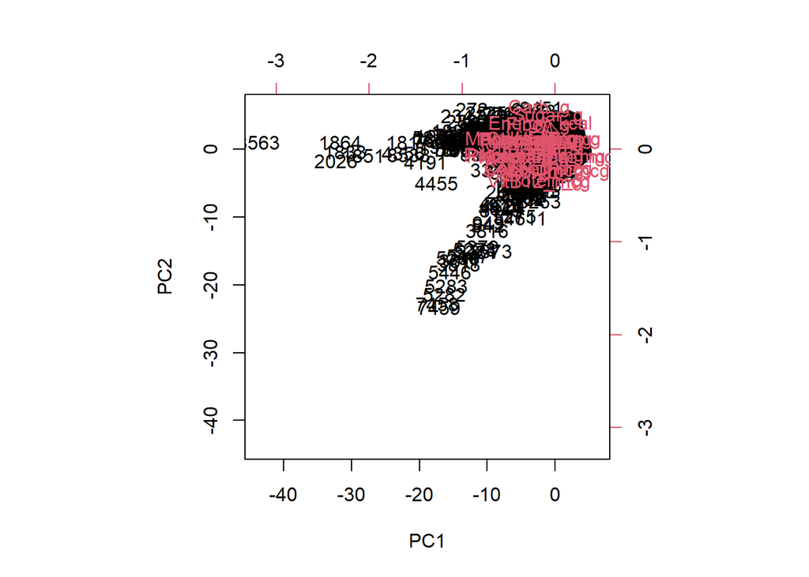

```r
biplot(nncomp, c(1, 2), scale=0)
```

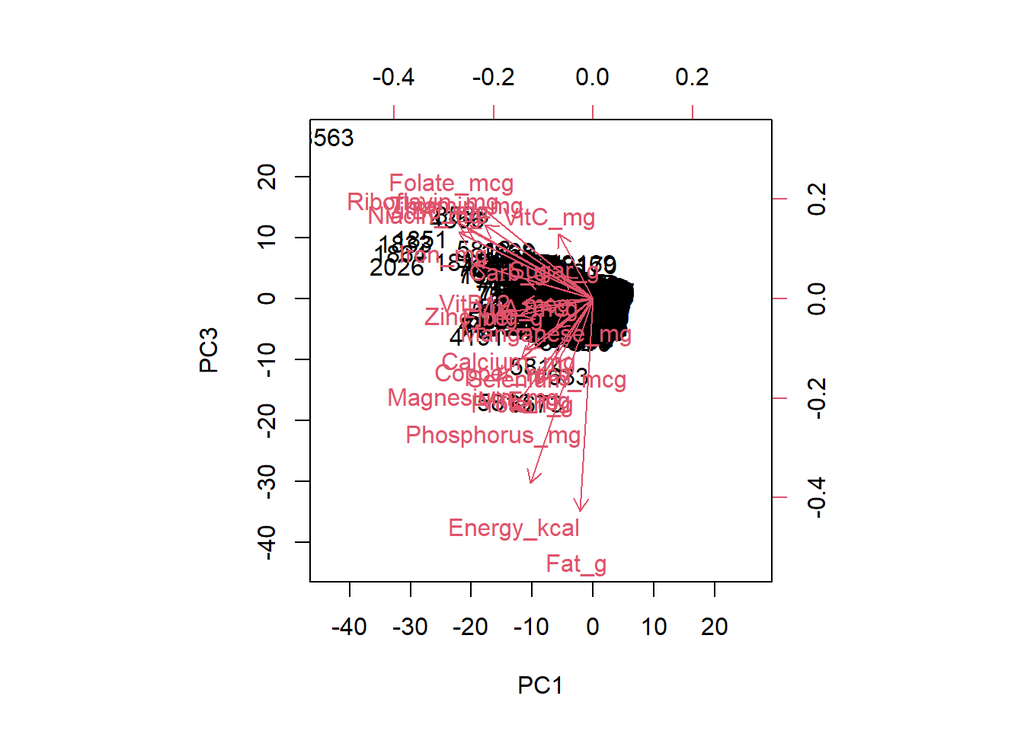

```r
biplot(nncomp, c(1, 3), scale=0)
```

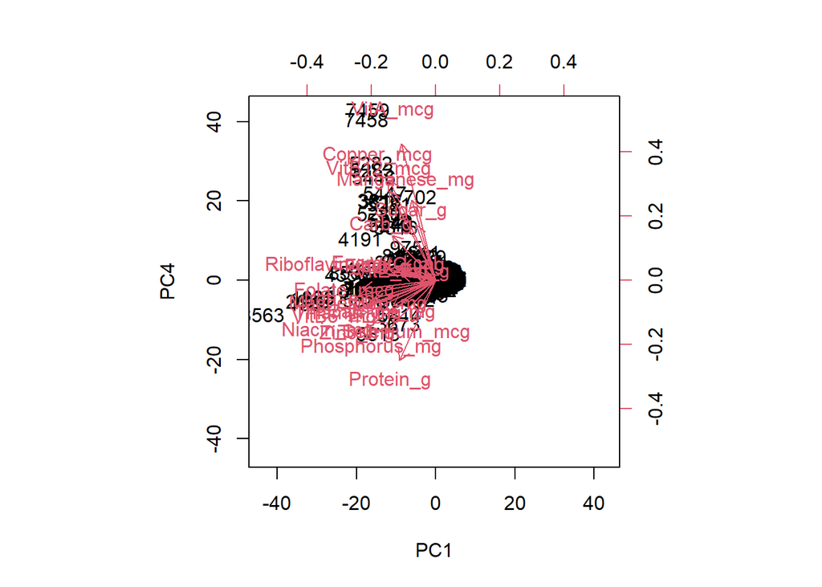

```r
biplot(nncomp, c(1, 4), scale=0)
```

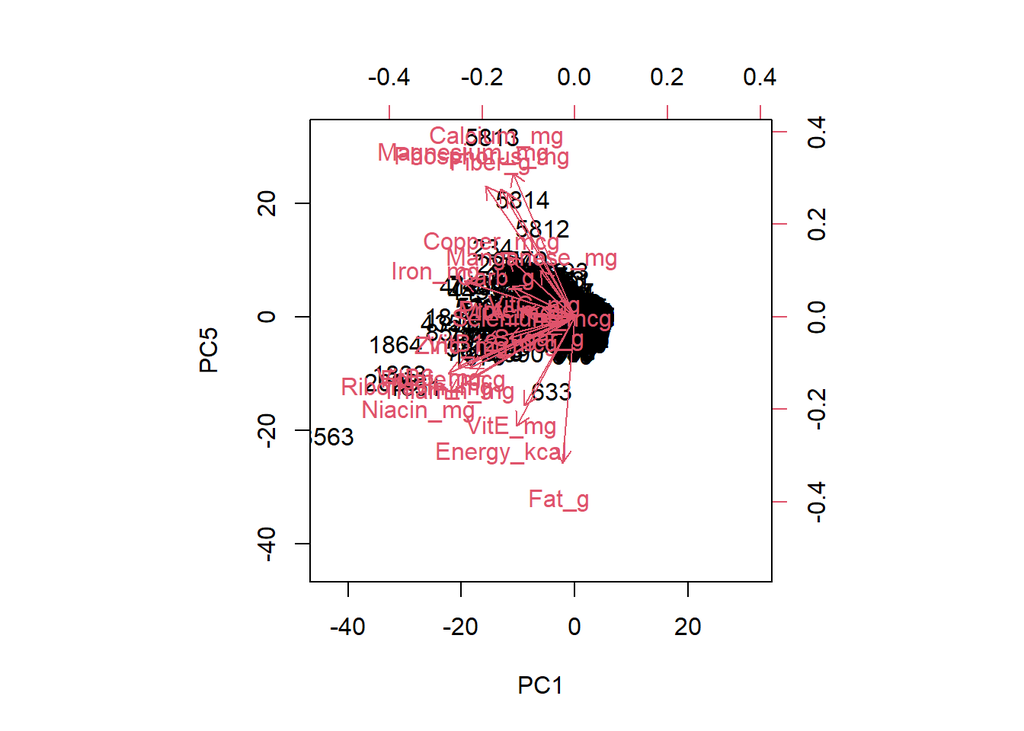

```r
biplot(nncomp, c(1, 5), scale=0)
```

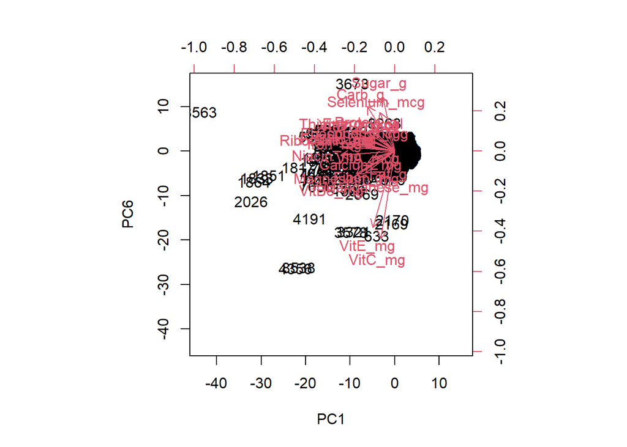

```r
biplot(nncomp, c(1, 6), scale=0)
```

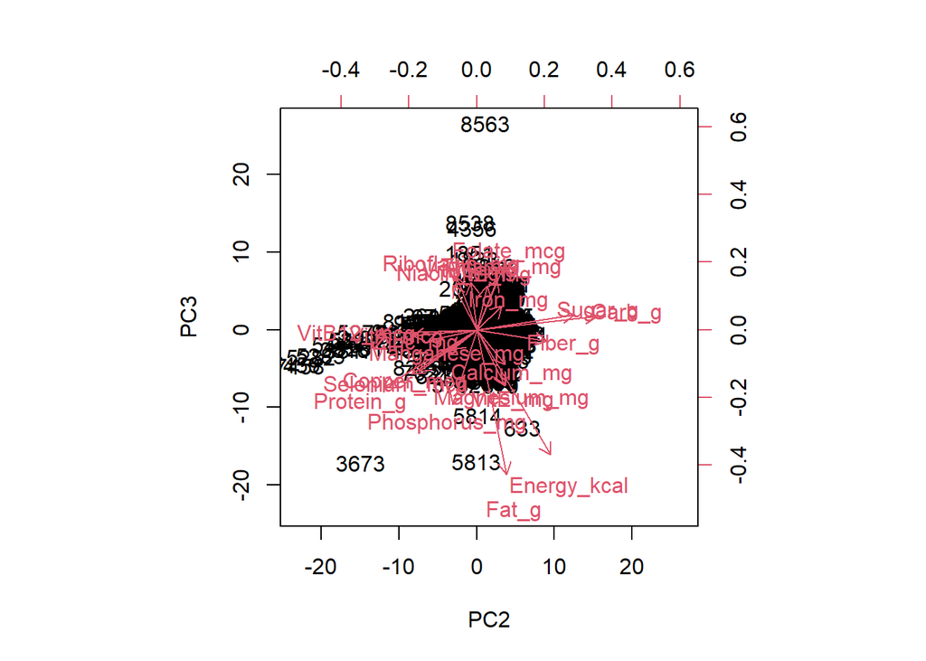

```r
biplot(nncomp, c(2, 3), scale=0)
```

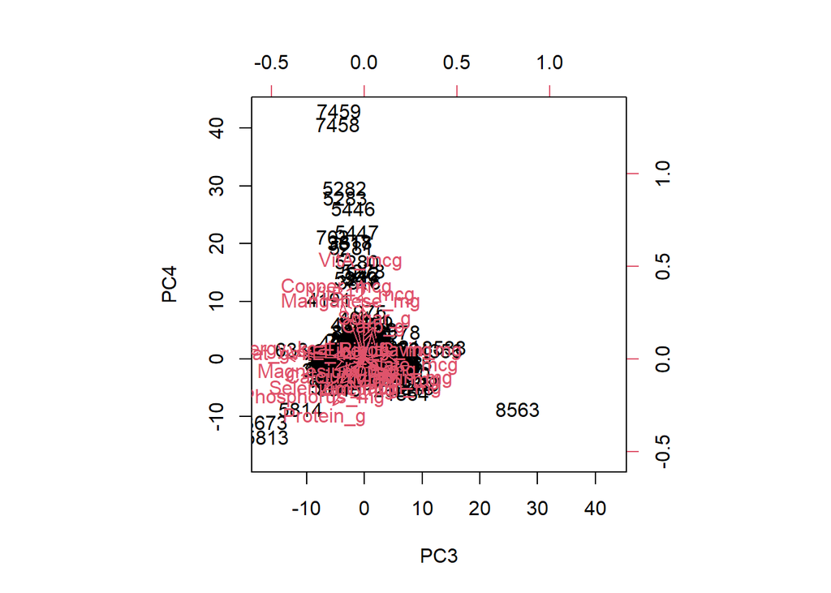

```r
biplot(nncomp, c(3, 4), scale=0)
```

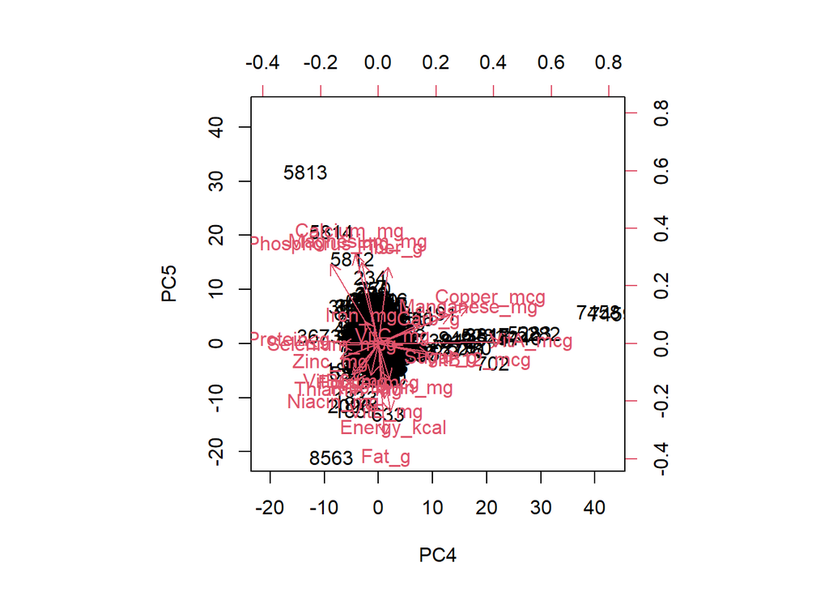

```r
biplot(nncomp, c(4, 5), scale=0)
```

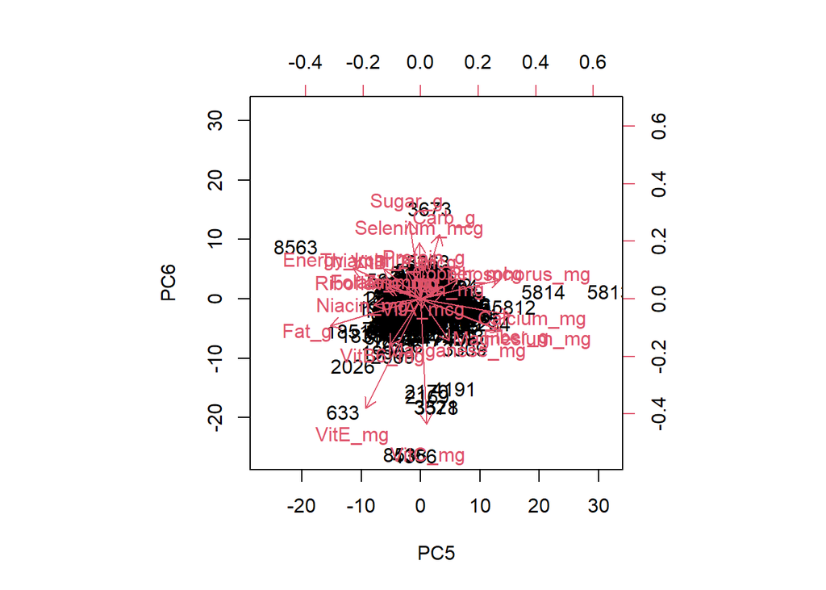

```r
biplot(nncomp, c(5, 6), scale=0)
```

### Question 8

**PVE**  
Does the plots show that `PC1` capture much more variance than `PC2`? `PC6`? (Of course we can confirm these with the PVE plot and calculations if we like. It is not required in this hw here.)

**Variance in each component**

```r
comp.var <- (nncomp$sdev)^2
comp.var <- comp.var / sum(comp.var)
comp.var <- data.frame(matrix(comp.var, nrow=1, ncol=23))
colnames(comp.var) <- sprintf("PC%d", seq(1,23))
rmarkdown::paged_table(comp.var)
```

| PC1 | PC2 | PC3 | PC4 | PC5 | PC6 | PC7 | PC8 | PC9 | PC10 | PC11 | PC12 | PC13 | PC14 | PC15 | PC16 | PC17 | PC18 | PC19 | PC20 | PC21 | PC22 | PC23 |
| --- | --- | --- | --- | --- | --- | --- | --- | --- | --- | --- | --- | --- | --- | --- | --- | --- | --- | --- | --- | --- | --- | --- |
| 0.237 | 0.114 | 0.0883 | 0.0817 | 0.0711 | 0.0496 | 0.0461 | 0.0403 | 0.0375 | 0.0359 | 0.0318 | 0.026 | 0.0221 | 0.0204 | 0.0177 | 0.0147 | 0.0143 | 0.014 | 0.0111 | 0.0104 | 0.00918 | 0.00692 | 0.000165 |

They are somewhat cluttered. However I did extracted some information.  
`PC1` captures more variance than `PC2` as I can see red arrows going little far on x-axis than on y-axis and `PC6` as well. This is also evident from seeing the normalized variance in each component.  
Yes `PC1` captures more variance than `PC6`. I can see variables loaded to near -40 hence yes `PC1` does capture more variance.

### Question 9

**Interesting plots**  
If you look at the plot between `PC1` and `PC2`, it looks like a boomerang shape. (See image file in the hw zip.) Recall that `PC1` and `PC2` consists of rather different linear combinations of the original variables. And `PC1`-`PC2` have zero correlation. The chart shows us although `PC1` and `PC2` are overall un-correlated, when `PC1` change, there are only two different trends that `PC2` will change, as if there are only two types of nutrients in the 8000+ observations. Maybe these two kinds of food/items should be analyzed separately with two different models. These are some of the patterns and structures that PCA might be able to reveal.

At any rate, do you see other charts showing unexpected patterns?

I am somewhat confused when you say When `PC1` change, there are only two different **trends** that `PC2` will change. Here is my understanding:  
In `PC1` vs `PC6` plot, I can see `VitE_mg` and `VitC_mg` are strong components in `PC6` as they are coming all the way near -30.  
In `PC2` vs `PC3` I can clearly see red arrows for `Energy_kcal` and `Fat_g` are near -20 on the y-axis while around 5 & 10 on x-axis. Hence these variables are more stronger in `PC3`.

## Optional

We will skip the model building using PCR here as it turns out not a productive exercise in that direction. While we are having this huge dataset, with 23 variables, this is actually a good candidate for performing the feature selection using leaps.

If you just look at the dataset and guess what are the good predictors to model Energy_kcal, what would you pick?

Now try run it by leaps regsubsets. What is the minimum number of predictors you will need, if you want to have a 90% $R^2$?